# Quiz 2

Amy Su Jiang

### Question 1

Under the lattice graphics system, what do the primary plotting functions like xyplot() and bwplot() return?

```
an object of class "trellis"
an object of class "lattice"
an object of class "plot"
nothing; only a plot is made
```

```
Answer: an object of class "trellis"
```

### Question 2

What is produced by the following code?

library(nlme) library(lattice) xyplot(weight ~ Time | Diet, BodyWeight)

```
A set of 3 panels showing the relationship between weight and time for each diet.
A set of 16 panels showing the relationship between weight and time for each rat.
A set of 11 panels showing the relationship between weight and diet for each time.
A set of 3 panels showing the relationship between weight and time for each rat.
```

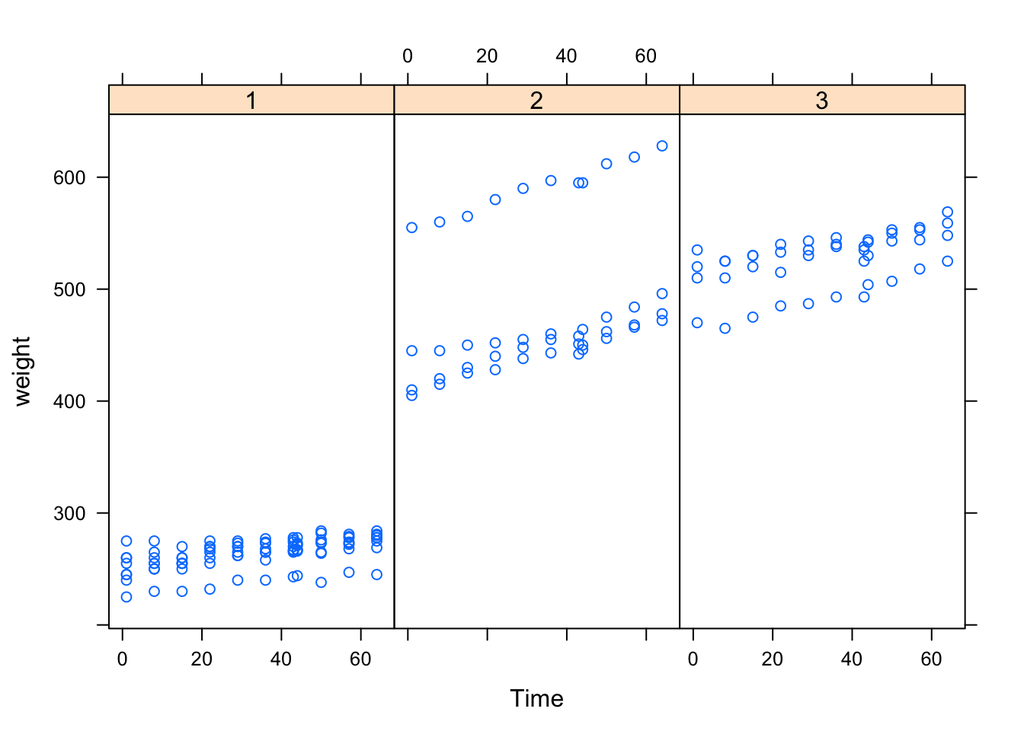

```r
library(nlme)
library(lattice)
xyplot(weight ~ Time | Diet, BodyWeight)
```

### Question 3

Annotation of plots in any plotting system involves adding points, lines, or text to the plot, in addition to customizing axis labels or adding titles. Different plotting systems have different sets of functions for annotating plots in this way. Which of the following functions can be used to annotate the panels in a multi-panel lattice plot?

```
points()
axis()
panel.abline()
lines()
```

```
Answer: panel.abline()
```

### Question 4

The following code does NOT result in a plot appearing on the screen device.

library(lattice) library(datasets) data(airquality) p <- xyplot(Ozone ~ Wind | factor(Month), data = airquality)

Which of the following is an explanation for why no plot appears?

```
The xyplot() function, by default, sends plots to the PDF device.
The variables being plotted are not found in that dataset.
The object 'p' has not yet been printed with the appropriate print method.
There is a syntax error in the call to xyplot().
```

```
Answer: The object 'p' has not yet been printed with the appropriate print method.
```

### Question 5

In the lattice system, which of the following functions can be used to finely control the appearance of all lattice plots?

```
par()
splom()
print.trellis()
trellis.par.set()
```

```
Answer: trellis.par.set()
```

### Question 6

What is ggplot2 an implementation of?

```
the Grammar of Graphics developed by Leland Wilkinson
the base plotting system in R
a 3D visualization system
the S language originally developed by Bell Labs
```

```
Answer: the Grammar of Graphics developed by Leland Wilkinson
```

### Question 7

Load the `airquality’ dataset form the datasets package in R.

library(datasets) data(airquality)

I am interested in examining how the relationship between ozone and wind speed varies across each month. What would be the appropriate code to visualize that using ggplot2?

```
airquality = transform(airquality, Month = factor(Month))
qplot(Wind, Ozone, data = airquality, facets = . ~ Month)

qplot(Wind, Ozone, data = airquality, geom = "smooth")

qplot(Wind, Ozone, data = airquality)

qplot(Wind, Ozone, data = airquality, facets = . ~ factor(Month))
```

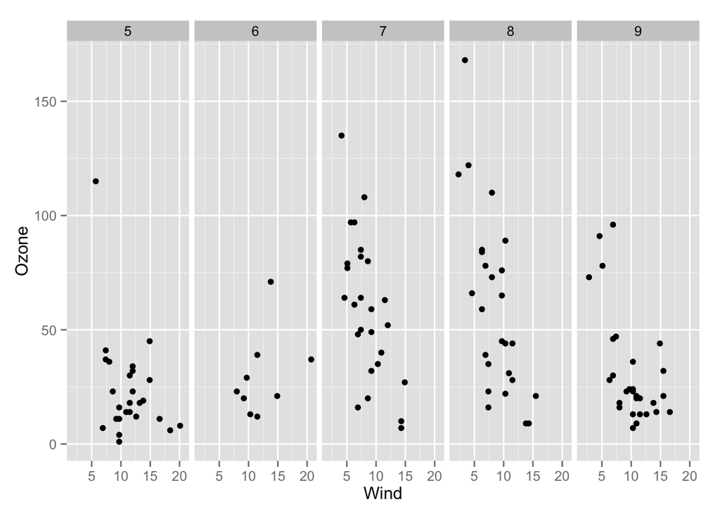

```r
library("ggplot2")
library(datasets)
data(airquality)

airquality = transform(airquality, Month = factor(Month))
qplot(Wind, Ozone, data = airquality, facets = . ~ Month)
```

### Question 8

What is a geom in the ggplot2 system?

```
a plotting object like point, line, or other shape
a method for mapping data to attributes like color and size
a statistical transformation
a method for making conditioning plots
```

```
Answer: a plotting object like point, line, or other shape
```

### Question 9

When I run the following code I get an error:

library(ggplot2) g <- ggplot(movies, aes(votes, rating)) print(g)

I was expecting a scatterplot of ‘votes’ and ‘rating’ to appear. What’s the problem?

```
The dataset is too large and hence cannot be plotted to the screen.
The object 'g' does not have a print method.
ggplot does not yet know what type of layer to add to the plot.
There is a syntax error in the call to ggplot.
```

```
Answer: ggplot does not yet know what type of layer to add to the plot.
```

### Question 10

The following code creates a scatterplot of ‘votes’ and ‘rating’ from the movies dataset in the ggplot2 package. After loading the ggplot2 package with the library() function, I can run

qplot(votes, rating, data = movies)

How can I modify the the code above to add a smoother to the scatterplot?

```
qplot(votes, rating, data = movies) + geom_smooth()
qplot(votes, rating, data = movies, panel = panel.loess)
qplot(votes, rating, data = movies, smooth = "loess")
qplot(votes, rating, data = movies) + stats_smooth("loess")
```

```
## geom_smooth: method="auto" and size of largest group is >=1000, so using gam with formula: y ~ s(x, bs = "cs"). Use 'method = x' to change the smoothing method.
```

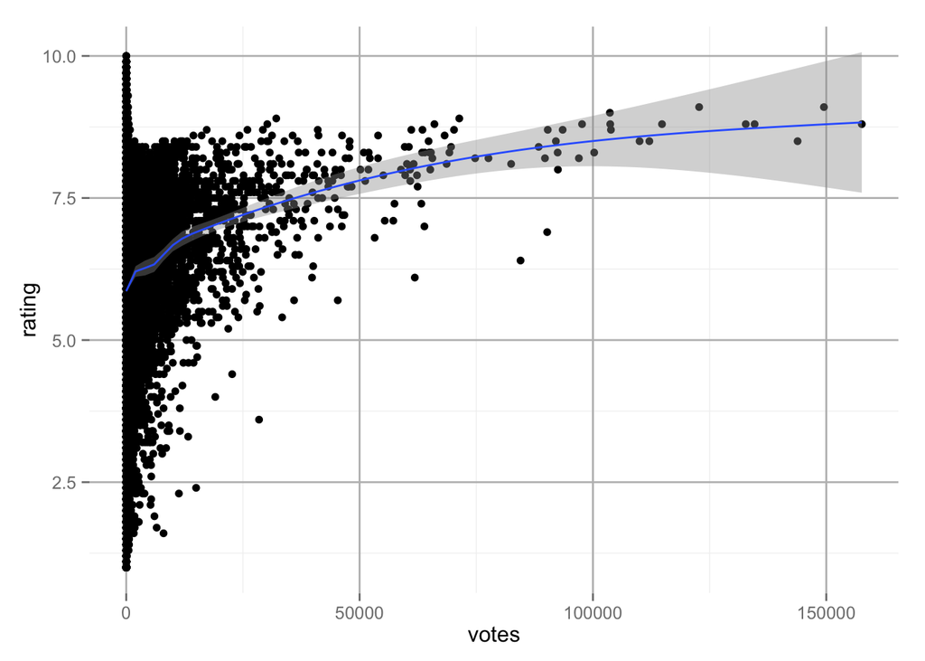

```r
library(ggplot2)
qplot(votes, rating, data = movies) + geom_smooth() + theme(
            panel.background = element_rect(fill="white"),
            panel.grid.major = element_line(colour = "grey")
    )
```